# An Introduction to R and RStudio

## What is R and why should you care

- R is a program for doing statistics and data analysis.
- R’s advantages or selling points relative to other programs (e.g, SPSS, SAS, Stata, Minitab, Python, Matlab, Maple, Mathematica, Tableau, Excel, SQL, and many others) come down to three inter-related factors:
  - It is immensely powerful.
  - It is open-source.
  - It is very and increasingly widely used.

## R: A power tool for data analysis

The range and depth of statistical analyses and general data analyses that can be accomplished with R is immense.

- Built into R are virtually the entire repertoire of widely known and used statistical methods.
- R has a vast set of add-on or contributed packages. There are presently (01 Nov, 2022) 18774 additional contributed packages.
- R is a programming language that is specialized to efficiently manipulate and perform calculations on data.
- The R programming language itself can be extended by interfacing with other programming languages (e.g. C/C++, Python, Spark, SQL).

## R: Open source software

- R is free and open source software, distributed according to the GNU public license.
- Likewise, virtually all of contributed R packages are likewise free and open source.
- In practical terms, this means that is freely available for everyone to use, now and forever, on more or less any device they choose.
- Open source software always has the potential to *go viral* and develop a large self-sustaining community of user/developers. This has arguably happened with R.

## A guided tour of RStudio

[figure not shown]

## Introducing R commands

- A useful way to think about R, and not an inaccurate one either, is that it is simply a calculator.

  ```r
  > 2 + 2 # addition
  ```

  ```
  #> [1] 4
  ```

  ```r
  > 3 - 5 # subtraction
  ```

  ```
  #> [1] -2
  ```

  ```r
  > 3 * 2 # multiplication
  ```

  ```
  #> [1] 6
  ```

  ```r
  > 4 / 3 # division
  ```

  ```
  #> [1] 1.333333
  ```

  ```r
  > (2 + 2) ^ (3 / 3.5) # exponents and brackets
  ```

  ```
  #> [1] 3.281341
  ```

## Variables and assignment

- If we type the following at the command prompt and then press Enter, the result is displayed but not stored.

  ```r
  > (12/3.5)^2 + (1/2.5)^3 + (1 + 2 + 3)^0.33
  ```

  ```
  #> [1] 13.6254
  ```

- We can, however, assign the value of the above calculation to a variable named `x`.

  ```r
  > x <- (12/3.5)^2 + (1/2.5)^3 + (1 + 2 + 3)^0.33
  ```

- Now, we can use `x` as is it were a number.

  ```r
  > x ^ 2
  ```

  ```
  #> [1] 185.6516
  ```

  ```r
  > x * 3.6
  ```

  ```
  #> [1] 49.05145
  ```

## Assignment rules

- In general, the assignment rule is

```
name <- expression
```

- The `expression` is any R code that returns some value.
- The `name` must consist of letters, numbers, dots, and underscores.

```
x123   # the following are acceptable
.x
x_y_z
xXx_123

_x   # the following are not acceptable
.2x
x-y-z
```

## Vectors

- Vectors are one dimensional sequences of values.
- For example, if we want to create a vector of the first 6 primes numbers, we could do the following.

  ```r
  > primes <- c(2, 3, 5, 7, 11, 13)
  ```

- We can now perform operations (arithmetic, logical, etc) on the `primes` vector.

  ```r
  > primes + 1
  ```

  ```
  #> [1]  3  4  6  8 12 14
  ```

  ```r
  > primes / 2
  ```

  ```
  #> [1] 1.0 1.5 2.5 3.5 5.5 6.5
  ```

  ```r
  > primes == 3
  ```

  ```
  #> [1] FALSE  TRUE FALSE FALSE FALSE FALSE
  ```

  ```r
  > primes >= 7
  ```

  ```
  #> [1] FALSE FALSE FALSE  TRUE  TRUE  TRUE
  ```

## Indexing vectors

- For any vector, we can refer to individual elements using indexing operations.

  ```r
  > primes[1]
  ```

  ```
  #> [1] 2
  ```

  ```r
  > primes[5]
  ```

  ```
  #> [1] 11
  ```

- If we want to refer to sets of elements, rather than just individual elements, we can use vectors (made with the `c()` function) inside the indexing square brackets.

  ```r
  > primes[c(3, 5, 2)]
  ```

  ```
  #> [1]  5 11  3
  ```

- If we use a negative valued index, we can refer to or all elements *except* one.

  ```r
  > primes[-1]
  ```

  ```
  #> [1]  3  5  7 11 13
  ```

  ```r
  > primes[-2]
  ```

  ```
  #> [1]  2  5  7 11 13
  ```

## Vector types

- A vector be a sequence of numbers, logical values, or characters.

  ```r
  > nation <- c('ireland', 'england', 'scotland', 'wales')
  ```

- We can index this vector as we did with a vector of numbers.

  ```r
  > nation[1]
  ```

  ```
  #> [1] "ireland"
  ```

  ```r
  > nation[2:3]
  ```

  ```
  #> [1] "england"  "scotland"
  ```

  ```r
  > nation == 'ireland'
  ```

  ```
  #> [1]  TRUE FALSE FALSE FALSE
  ```

- The `class` function in R will identify the data type of the vector.

  ```r
  > class(primes)
  ```

  ```
  #> [1] "numeric"
  ```

  ```r
  > class(nation)
  ```

  ```
  #> [1] "character"
  ```

## Logical vectors

- Another widely used type of vector is a logical or Boolean vector.

  ```r
  > is_male <- c(TRUE, FALSE, TRUE, TRUE, FALSE)
  ```

- This could also be created more succinctly as follows.

  ```r
  > is_male <- c(T, F, T, T, F)
  ```

- Using `class`, we can verify that this vector is a logical vector.

  ```r
  > class(is_male)
  ```

  ```
  #> [1] "logical"
  ```

- We can index logical vectors just like numeric or character vectors.

  ```r
  > is_male[2]
  ```

  ```
  #> [1] FALSE
  ```

  ```r
  > is_male[2:4]
  ```

  ```
  #> [1] FALSE  TRUE  TRUE
  ```

## Coercing vectors

- An important property of all vectors is that they are homogeneous.
- If we try to make a heterogeneous vector, some our elements will be *coerced* into other types.

  ```r
  > c(TRUE, FALSE, 3, 2, -1, TRUE)
  ```

  ```
  #> [1]  1  0  3  2 -1  1
  ```

  ```r
  > c(2.75, 11.3, TRUE, FALSE, 'dog', 'cat')
  ```

  ```
  #> [1] "2.75"  "11.3"  "TRUE"  "FALSE" "dog"   "cat"
  ```

## Combining vectors

- We can combine vectors with `c()`.
- For example, to combine the `primes` vector, with the vectors that are the squares and cubes of `primes`, we would do the following:

  ```r
  > c(primes, primes^2, primes^3)
  ```

  ```
  #>  [1]    2    3    5    7   11   13    4    9   25   49  121  169    8   27  125
  #> [16]  343 1331 2197
  ```

## Missing values

- In any vector, there can be missing values.
- In R, missing values are denoted by `NA`.

  ```r
  > c(1, 2, NA, 4, 5)
  ```

  ```
  #> [1]  1  2 NA  4  5
  ```

  ```r
  > c('be', NA, 'afeard')
  ```

  ```
  #> [1] "be"     NA       "afeard"
  ```

## Data frames

- Data frames are rectangular data structures; they have certain number of columns, and each column has the same number of rows. Each column is in fact a vector.
- Usually, data frames are created when read in the contents of a data file, but we can produce them on the command line with the `data.frame()`.

  ```r
  > Df <- data.frame(name = c('billy', 'joe', 'bob'),
  +                  age = c(21, 29, 23))
  > Df
  ```

  ```
  #>    name age
  #> 1 billy  21
  #> 2   joe  29
  #> 3   bob  23
  ```

## Indexing data frames

- We can refer to elements of a data frame in different ways.
- The simplest is to use double indices, one for the rows, one for the columns.

  ```r
  > Df[3, 2] # row 3, col 2
  ```

  ```
  #> [1] 23
  ```

  ```r
  > Df[c(1, 3), 2] # rows 1 and 3, col 2
  ```

  ```
  #> [1] 21 23
  ```

  ```r
  > Df[1,] # row 1, all cols
  ```

  ```
  #>    name age
  #> 1 billy  21
  ```

  ```r
  > Df[, 2] # all rows, col 2
  ```

  ```
  #> [1] 21 29 23
  ```

## Indexing data frames (contined)

- We could also refer to the column by name. To do so, we could use the following `$` notation.

  ```r
  > Df$age
  ```

  ```
  #> [1] 21 29 23
  ```

- An alternative syntax that accomplishes the same thing is to use *double* square brackets as follows.

  ```r
  > Df[['age']]
  ```

  ```
  #> [1] 21 29 23
  ```

- A *single* square brackets, we would obtain the following.

  ```r
  > Df['age']
  ```

  ```
  #>   age
  #> 1  21
  #> 2  29
  #> 3  23
  ```

## Functions

- In functions, we put data in, calculations or done to or using this data, and new data, perhaps just a single value, is then returned.
- There are probably hundreds of thousands of functions in R.
- For example,

  ```r
  > length(primes)
  ```

  ```
  #> [1] 6
  ```

  ```r
  > sum(primes)
  ```

  ```
  #> [1] 41
  ```

  ```r
  > mean(primes)
  ```

  ```
  #> [1] 6.833333
  ```

  ```r
  > median(primes)
  ```

  ```
  #> [1] 6
  ```

  ```r
  > sd(primes)
  ```

  ```
  #> [1] 4.400758
  ```

  ```r
  > var(primes)
  ```

  ```
  #> [1] 19.36667
  ```

## Custom functions

- R makes it easy to create new functions.

  ```r
  > my_mean <- function(x){ sum(x)/length(x)}
  ```

- This `my_mean` takes a vector as input and divides its sum by the number of elements in it. It then returns this values. The `x` is a placeholder for whatever variable we input into the function.
- We would use it just as we would use `mean`.

  ```r
  > my_mean(primes)
  ```

  ```
  #> [1] 6.833333
  ```

## Writing R scripts

- Scripts are files where we write R commands, which can be then saved for later use.
- You can bring up RStudio’s script editor with Ctrl+Shift+N, or go to the File/ New File/ R script, or click on the New icon on the left of the taskbar below the menu and choose R script.
- In a script, you can have as many lines of code as you wish, and there can be as many blank lines as you wish.

```r
composites <- c(4, 6, 8, 9, 10, 12)

composites_plus_one <- composites + 1

composites_minus_one <- composites - 1
```

- If you place the cursor on line 1, you can then click the Run icon, or press the Ctrl+Enter keys.

## Writing R scripts (continued)

One reason why writings in scripts is very practically valuable, even if you don’t wish to save the scripts, is when you are write long and complex commands.

```r
Df <- data.frame(name = c('jane', 'joe', 'billy'),
                 age = c(23, 27, 24),
                 sex = c('female', 'male', 'male'),
                 occupation = c('tinker', 'tailor', 'spy')
)
```

We can execute this command as if it were on a single line by placing the cursor anywhere on any line and pressing Ctrl+Enter.

## Code comments

- An almost universal feature of programming language is the option to write *comments* in the code files.
- A comment allows you write to notes or comments around the code that is then skipped over when the script or the code lines are being executed.
- In R, anything following the `#` symbol on any line is treated as a comment.

```r
# Here is a data frame with four variables.
# The variables are name, age, sex, occupation.
Df <- data.frame(name = c('jane', 'joe', 'billy'),
                 # This line is a comment too.
                 age = c(23, 27, 24), # Another comment.
                 sex = c('female','male', 'male'),
                 occupation = c('tinker', 'tailor', 'spy')
)
```

## Packages

- There are presently 18774 contributed packages in R.
- The easiest way to install a package is to click the Install button on the top left of the *Packages* window in the lower right pane.
- You can also install a package or packages with the `install.packages` command.

  ```r
  > install.packages("dplyr")
  > install.packages(c("dplyr", "tidyr", "ggplot2"))
  ```

- Having installed a package, it must be loaded to be used. This can be done by clicking the tick box before the package name in the *Packages* window, or use the `library` command.

  ```r
  > library("tidyverse")
  ```

## Reading in data

- R allows you to import data from a very large variety of data file types, including from other statistics programs like SPSS, Stata, SAS, Minitab, and so on, and common file formats like `.xlsx` and `.csv`.
- When learning R initially, the easiest way to import data is using the Import Dataset button in the Environment window.
- If we use the *From Text (readr)…* option, it runs the `read_csv` R command, which we can run ourselves on the command line, or write in a script.

  ```r
  > library(readr)
  > test_data <- read_csv("data/data01.csv")
  ```

## Viewing data

- The easiest way to view a data frames is to type its name.

  ```r
  > test_data
  ```

  ```
  #> # A tibble: 100 × 3
  #>    sex       iq test_score
  #>    <chr>  <dbl>      <dbl>
  #>  1 male      74       14.1
  #>  2 female    83       16.0
  #>  3 female    88       15.6
  #>  4 male     105       11.8
  #>  5 male      92       13.5
  #>  6 male      92       13.4
  #>  7 male     102       12.7
  #>  8 female    80       14.9
  #>  9 male     102       14.1
  #> 10 female   114       15.7
  #> # … with 90 more rows
  ```

## Viewing data (continued)

- Another option to view a data frame is to `glimpse` it.

  ```r
  > library(dplyr)
  > glimpse(test_data)
  ```

  ```
  #> Rows: 100
  #> Columns: 3
  #> $ sex        <chr> "male", "female", "female", "male", "male", "male", "male",…
  #> $ iq         <dbl> 74, 83, 88, 105, 92, 92, 102, 80, 102, 114, 107, 80, 106, 6…
  #> $ test_score <dbl> 14.14571, 16.01274, 15.64022, 11.82935, 13.48280, 13.36010,…
  ```

## Working directory, RStudio projects, and clean workspaces

- Every R session has a *working directory*, which we can think of as the directory (aka folder) on the computer’s filesystem in which the R session is running.
- On Windows, this will appear something like the following.

  ```r
  > getwd()
  > #> [1] "C:/Users/andrews"
  ```

  On Macs, it will appear something like the following.

  ```r
  > getwd()
  > #> /Users/andrews/
  ```

- The working directory is that it is the default location from which files are read and to which files are written whenever we are using *relative* rather than *absolute* path names.
- The use of relative paths is necessary to allow our R scripts to be usable either by others or by ourselves on different devices.

An absolute path name gives the exact location of the file on the file system by specifying the file’s name, the directory it is in, the directory in which its directory is located, and so on, up to the root of the filesystem. For example, on a Windows machine, an absolute path name for a file might be `C:/Users/andrews/Downloads/data/data.csv`. From this, we see that the file `data.csv` is a directory named `data` that is in `Downloads` in `andrews` in `Users` on the `C` drive. We could read this file into R with the following command.

```r
data_df <- read_csv("C:/Users/andrews/Downloads/data/data.csv")
```

## Relative and absolute paths

- The following uses an absolute path:

```r
data_df <- read_csv("C:/Users/andrews/Downloads/data/data.csv")
```

- In general, R scripts that use absolute path names are not usable either by others or by ourselves on different machines.

On the other hand, the relative path based command

```r
data_1_df <- read_csv("data.csv")
```

will work assuming that `data.csv` is in the session’s working directory

## RStudio projects

- When we are working on a particular data analysis task, it is usually a good idea to set the working directory to be the directory where all these scripts and data files are located.
- To facilitate this, RStudio allows us to set our `data_analysis` directory as an *RStudio project*.
- Whenever we open a project, or switch between projects, our working directory is then automatically switched to the project’s directory.
- RStudio projects can then be shared with others.

## Clean workspaces

- In general, R allows us to always save the contents of our *workspace* to a file, usually named `.RData`, when terminating our session.
- However, rather than saving many data frames that we have derived from processing some raw data that we initially imported, it is far better to have a single script that reads the raw data and then runs a series of commands on this data, thus creating, or re-created, all the derived data frames.
- RStudio projects also give us the option of always saving or never saving our workspace, and always or never loading the workspace file at startup.
- We recommend that we always set these options to *never* save nor load the contents of the workspace.
- At any point during our RStudio session, we can restart R itself through `Session > Restart R`.

## Summarizing data with `summary`

- An easy way to summarize a data frame is with `summary`.

  ```r
  > summary(test_data)
  ```

  ```
  #>      sex                  iq          test_score
  #>  Length:100         Min.   : 60.0   Min.   :11.49
  #>  Class :character   1st Qu.: 91.0   1st Qu.:13.26
  #>  Mode  :character   Median :102.0   Median :14.63
  #>                     Mean   :100.4   Mean   :14.50
  #>                     3rd Qu.:108.2   3rd Qu.:15.65
  #>                     Max.   :138.0   Max.   :18.40
  ```

## Summarizing data with `summarize`

- The `summarize` (or `summarise`) command is a flexible way of getting summary statistics.

  ```r
  # requires library(tidyverse) or library(dplyr)
  summarize(test_data,
            average_iq = mean(iq),
            average_score = mean(test_score),
            iq_stdev = sd(iq),
            score_var = var(test_score),
            n = n()
  )
  ```

  ```
  #> # A tibble: 1 × 5
  #>   average_iq average_score iq_stdev score_var     n
  #>        <dbl>         <dbl>    <dbl>     <dbl> <int>
  #> 1       100.          14.5     14.5      2.30   100
  ```

## Summarizing data `by_group`

- We can group the data frame into subsets based on the value of `sex` and then summarize.

  ```r
  summarize(group_by(test_data, sex),
            average_iq = mean(iq),
            average_score = mean(test_score),
            iq_stdev = sd(iq),
            score_var = var(test_score),
            n = n()
  )
  ```

  ```
  #> # A tibble: 2 × 6
  #>   sex    average_iq average_score iq_stdev score_var     n
  #>   <chr>       <dbl>         <dbl>    <dbl>     <dbl> <int>
  #> 1 female      101.           15.4     15.6      1.46    51
  #> 2 male         99.6          13.6     13.4      1.48    49
  ```

## Plots and data visualiztion

- The best way to data visualization in R is with `ggplot2`.

  ```r
  library(ggplot2)
  ```

- `ggplot2` is package whose main function is `ggplot`.
- `ggplot` is a *layered* plotting system where we map variables to aesthetic properties of a graphic and then add layers.

## Scatterplot

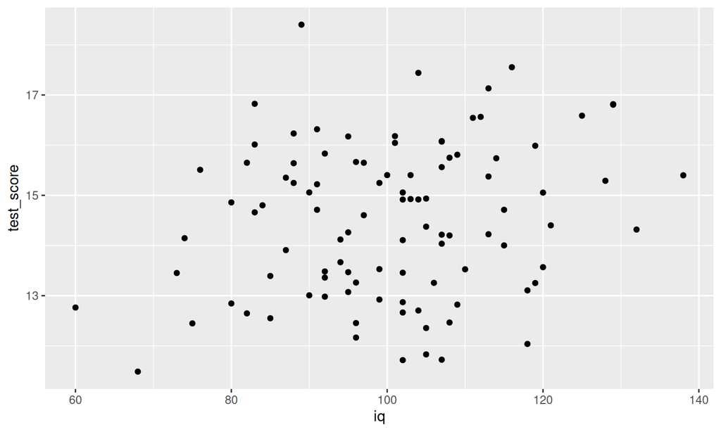

```r
ggplot(test_data,
       aes(x = iq, y = test_score)
) + geom_point()
```

## Scatterplot with `sex` indicated by colour

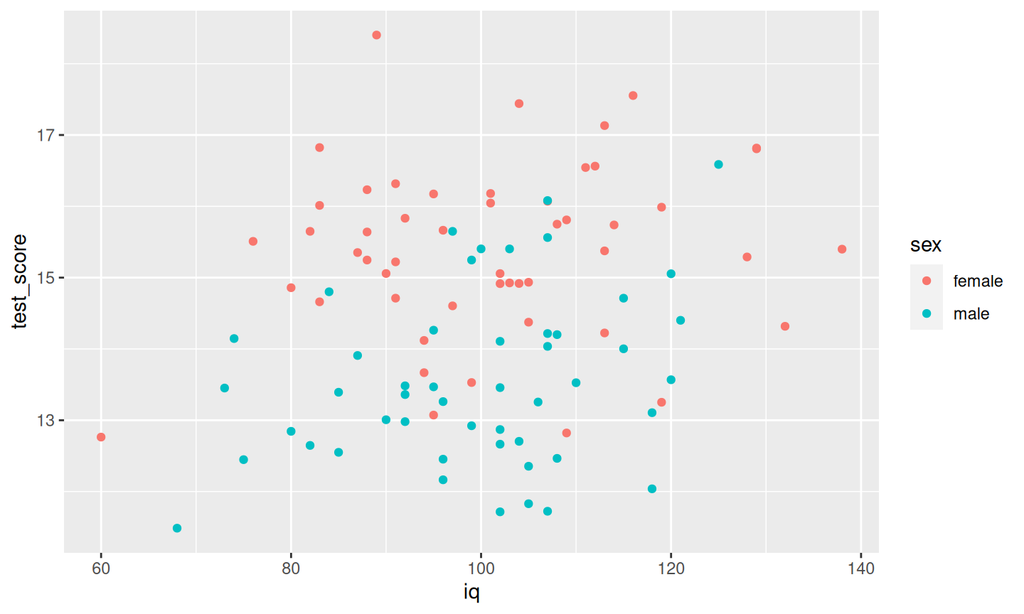

```r
ggplot(test_data,
       aes(x = iq, y = test_score, col = sex)
) + geom_point()
```

## Scatterplot with line of best fit

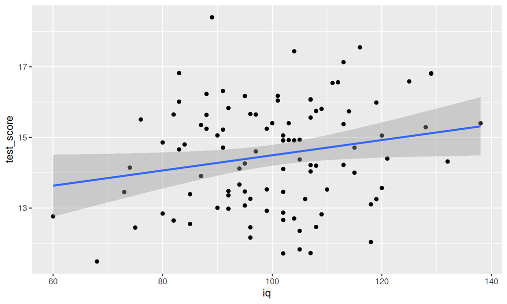

```r
ggplot(test_data,
       aes(x = iq, y = test_score)
) + geom_point() +
  stat_smooth(method = 'lm')
```

## Scatterplot with line of best fit, for each value of `sex`

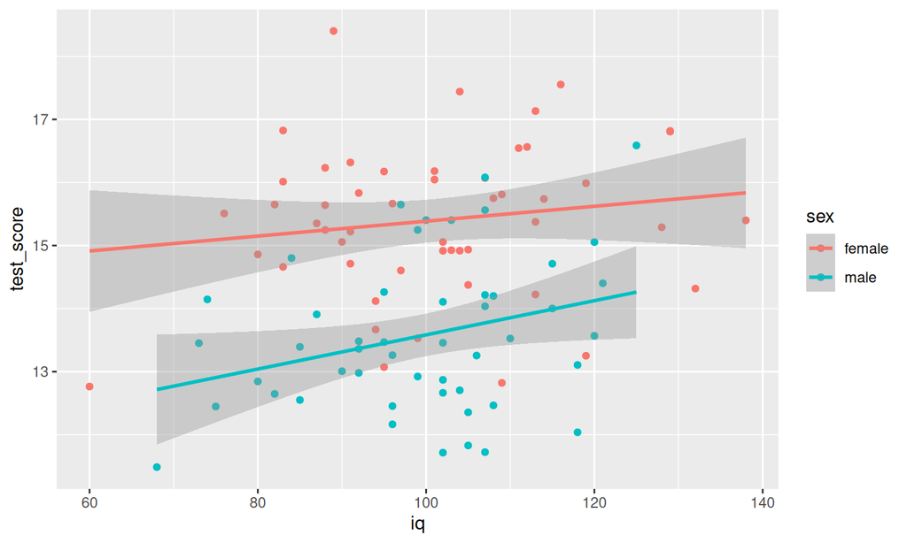

```r
ggplot(test_data,
       aes(x = iq, y = test_score, col = sex)
) + geom_point() +
  stat_smooth(method = 'lm')
```

## Changing style of a plot

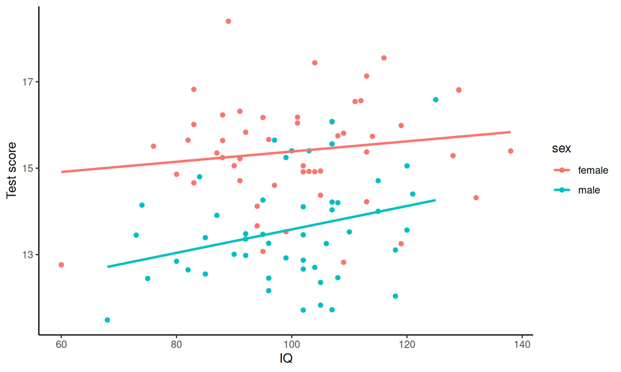

```r
ggplot(test_data,
       aes(x = iq, y = test_score, col=sex)
) + geom_point() +
  stat_smooth(method='lm', se=F) +
  theme_classic() +
  xlab('IQ') +
  ylab('Test score')
```

## Linear regression

- Predict `ACT` as a linear function of `education` in the `sat_act` data frame.

  ```r
  sat_act <- read_csv('data/sat_act.csv')
  M <- lm(ACT ~ education, data=sat_act)
  summary(M)
  ```

  ```
  #>
  #> Call:
  #> lm(formula = ACT ~ education, data = sat_act)
  #>
  #> Residuals:
  #>      Min       1Q   Median       3Q      Max
  #> -24.9371  -3.4251   0.5389   3.5389   9.1108
  #>
  #> Coefficients:
  #>             Estimate Std. Error t value  Pr(>|t|)
  #> (Intercept)  26.8892     0.4391   61.23   < 2e-16 ***
  #> education     0.5240     0.1265    4.14 0.0000389 ***
  #> ---
  #> Signif. codes:  0 '***' 0.001 '**' 0.01 '*' 0.05 '.' 0.1 ' ' 1
  #>
  #> Residual standard error: 4.769 on 698 degrees of freedom
  #> Multiple R-squared:  0.02397,    Adjusted R-squared:  0.02257
  #> F-statistic: 17.14 on 1 and 698 DF,  p-value: 0.0000389
  ```

## Multiple linear regression

- We can add as many predictor variables as we like.

  ```r
  M <- lm(ACT ~ education + age + gender, data=sat_act)
  summary(M)
  ```

  ```
  #>
  #> Call:
  #> lm(formula = ACT ~ education + age + gender, data = sat_act)
  #>
  #> Residuals:
  #>      Min       1Q   Median       3Q      Max
  #> -25.2458  -3.2133   0.7769   3.5921   9.2630
  #>
  #> Coefficients:
  #>             Estimate Std. Error t value Pr(>|t|)
  #> (Intercept) 27.41706    0.82140  33.378  < 2e-16 ***
  #> education    0.47890    0.15235   3.143  0.00174 **
  #> age          0.01623    0.02278   0.712  0.47650
  #> gender      -0.48606    0.37984  -1.280  0.20110
  #> ---
  #> Signif. codes:  0 '***' 0.001 '**' 0.01 '*' 0.05 '.' 0.1 ' ' 1
  #>
  #> Residual standard error: 4.768 on 696 degrees of freedom
  #> Multiple R-squared:  0.0272, Adjusted R-squared:  0.02301
  #> F-statistic: 6.487 on 3 and 696 DF,  p-value: 0.0002476
  ```